# Project: Investigating TMDb_Movie_Dataset

- Introduction
- Data Cleaning
- Data Wrangling
- Exploratory Data Analysis
- Conclusions

## Introduction

> I am choosing TMDb movie dataset to investigate. This data set contains information about 10,000 movies collected from The Movie Database (TMDb), including user ratings and revenue. Certain columns, like ‘cast’ and ‘genres’, contain multiple values separated by pipe (|) characters. There are some odd characters in the ‘cast’ column.

> So let's check how TMDb movie database csv file looks like.

```python
import pandas as pd
#loading the csv file and storing it in the variable "TMDb_data"
TMDb_data = pd.read_csv('tmdb-movies.csv')

#printing first five rows with defined columns of tmdb-movies database
TMDb_data.head()
```

|  | id | imdb_id | popularity | budget | revenue | original_title | cast | homepage | director | tagline | ... | overview | runtime | genres | production_companies | release_date | vote_count | vote_average | release_year | budget_adj | revenue_adj |
| --- | --- | --- | --- | --- | --- | --- | --- | --- | --- | --- | --- | --- | --- | --- | --- | --- | --- | --- | --- | --- | --- |
| 0 | 135397 | tt0369610 | 32.985763 | 150000000 | 1513528810 | Jurassic World | Chris Pratt\|Bryce Dallas Howard\|Irrfan Khan\|Vi... | http://www.jurassicworld.com/ | Colin Trevorrow | The park is open. | ... | Twenty-two years after the events of Jurassic ... | 124 | Action\|Adventure\|Science Fiction\|Thriller | Universal Studios\|Amblin Entertainment\|Legenda... | 6/9/15 | 5562 | 6.5 | 2015 | 1.379999e+08 | 1.392446e+09 |
| 1 | 76341 | tt1392190 | 28.419936 | 150000000 | 378436354 | Mad Max: Fury Road | Tom Hardy\|Charlize Theron\|Hugh Keays-Byrne\|Nic... | http://www.madmaxmovie.com/ | George Miller | What a Lovely Day. | ... | An apocalyptic story set in the furthest reach... | 120 | Action\|Adventure\|Science Fiction\|Thriller | Village Roadshow Pictures\|Kennedy Miller Produ... | 5/13/15 | 6185 | 7.1 | 2015 | 1.379999e+08 | 3.481613e+08 |
| 2 | 262500 | tt2908446 | 13.112507 | 110000000 | 295238201 | Insurgent | Shailene Woodley\|Theo James\|Kate Winslet\|Ansel... | http://www.thedivergentseries.movie/#insurgent | Robert Schwentke | One Choice Can Destroy You | ... | Beatrice Prior must confront her inner demons ... | 119 | Adventure\|Science Fiction\|Thriller | Summit Entertainment\|Mandeville Films\|Red Wago... | 3/18/15 | 2480 | 6.3 | 2015 | 1.012000e+08 | 2.716190e+08 |
| 3 | 140607 | tt2488496 | 11.173104 | 200000000 | 2068178225 | Star Wars: The Force Awakens | Harrison Ford\|Mark Hamill\|Carrie Fisher\|Adam D... | http://www.starwars.com/films/star-wars-episod... | J.J. Abrams | Every generation has a story. | ... | Thirty years after defeating the Galactic Empi... | 136 | Action\|Adventure\|Science Fiction\|Fantasy | Lucasfilm\|Truenorth Productions\|Bad Robot | 12/15/15 | 5292 | 7.5 | 2015 | 1.839999e+08 | 1.902723e+09 |
| 4 | 168259 | tt2820852 | 9.335014 | 190000000 | 1506249360 | Furious 7 | Vin Diesel\|Paul Walker\|Jason Statham\|Michelle ... | http://www.furious7.com/ | James Wan | Vengeance Hits Home | ... | Deckard Shaw seeks revenge against Dominic Tor... | 137 | Action\|Crime\|Thriller | Universal Pictures\|Original Film\|Media Rights ... | 4/1/15 | 2947 | 7.3 | 2015 | 1.747999e+08 | 1.385749e+09 |

5 rows × 21 columns

```python
# checking how many rows and columns this dataset contains
rows, col = TMDb_data.shape
print('There are {} total entries of movies and {} respective columns in dataset now.'.format(rows-1, col))
```

```
There are 10865 total entries of movies and 21 respective columns in dataset now.
```

#### Overview on Provided Dataset

- As we see dataset contains 10865 rows and 21 columns.
- We are assuming currency USD for columns 'budget', 'revenue', 'budget_adj', 'revenue_adj'
- 'realease_date' column values has to be arranged in correct format.

# Questions comes to mind after overview of dataset :

1. Which movie was most and least profitable?
2. Which movie had the greatest and least runtime?
3. Which movie had the Maximum and Minimum budget?
4. Which year most number of profitable movies were produced?
5. Which genre were more successful?
6. Which cast has appeared the most?
7. Directors with maximum releases over the years?
8. Which month made the most profit?
9. What is average budget for profitable movie?
10. What is the average runtime for profitable movies?

## Data Cleaning

Removing columns which are not needed

```python
#importing libraries we need for our analysis
import numpy as np
from matplotlib import pyplot as plt
import seaborn as sns

#defining list of columns to be deleted
del_col=[ 'id', 'imdb_id', 'popularity', 'budget_adj', 'revenue_adj', 'homepage', 'keywords', 'overview', 'production_companies', 'vote_count', 'vote_average']

#deleting the columns
TMDb_data= TMDb_data.drop(del_col,1)

#checking the new dataset
TMDb_data.head(5)
```

|  | budget | revenue | original_title | cast | director | tagline | runtime | genres | release_date | release_year |
| --- | --- | --- | --- | --- | --- | --- | --- | --- | --- | --- |
| 0 | 150000000 | 1513528810 | Jurassic World | Chris Pratt\|Bryce Dallas Howard\|Irrfan Khan\|Vi... | Colin Trevorrow | The park is open. | 124 | Action\|Adventure\|Science Fiction\|Thriller | 6/9/15 | 2015 |
| 1 | 150000000 | 378436354 | Mad Max: Fury Road | Tom Hardy\|Charlize Theron\|Hugh Keays-Byrne\|Nic... | George Miller | What a Lovely Day. | 120 | Action\|Adventure\|Science Fiction\|Thriller | 5/13/15 | 2015 |
| 2 | 110000000 | 295238201 | Insurgent | Shailene Woodley\|Theo James\|Kate Winslet\|Ansel... | Robert Schwentke | One Choice Can Destroy You | 119 | Adventure\|Science Fiction\|Thriller | 3/18/15 | 2015 |
| 3 | 200000000 | 2068178225 | Star Wars: The Force Awakens | Harrison Ford\|Mark Hamill\|Carrie Fisher\|Adam D... | J.J. Abrams | Every generation has a story. | 136 | Action\|Adventure\|Science Fiction\|Fantasy | 12/15/15 | 2015 |
| 4 | 190000000 | 1506249360 | Furious 7 | Vin Diesel\|Paul Walker\|Jason Statham\|Michelle ... | James Wan | Vengeance Hits Home | 137 | Action\|Crime\|Thriller | 4/1/15 | 2015 |

#### Now let's clean the dataset for any duplicate rows present.

```python
# Removing the duplicate rows(if any).
#We will drop duplicate rows keeping the first one

TMDb_data.drop_duplicates(keep = 'first', inplace = True)

# Lets see how many entries we have in the database

rows, col = TMDb_data.shape
print('There are {} total entries of movies and {} respective columns in dataset now.'.format(rows-1, col))
```

```
There are 10864 total entries of movies and 10 respective columns in dataset now.
```

As we see above that before we had 10865 rows and now it shows 10864 which means 1 duplicate row was found and cleared.

#### Let's delete movies which have '0' as value for revenue or budget from database.

```python
# defining list of revenue and budget column
data_list=['budget', 'revenue']

#we will replace all the values from '0' to NAN in the list
TMDb_data[data_list] = TMDb_data[data_list].replace(0, np.NAN)

#Removing all the row which has NaN value in temp_list
TMDb_data.dropna(subset = data_list, inplace = True)
# checking database after deletion '0' value entries
rows, col = TMDb_data.shape
print('After removing such entries, there are now {} no.of movies.'.format(rows-1))
```

```
After removing such entries, there are now 3853 no.of movies.
```

#### Also, we will replace with NaN for any movie with a runtime value of 0.

```python
#replacing 0 with NaN of 'runtime' column of the dataframe
TMDb_data['runtime'] = TMDb_data['runtime'].replace(0, np.NaN)
```

## Data Wrangling

#### We will now convert the 'release_date' column to date format as we mentioned in overview

```python
# Changing the release date column into standard date format
TMDb_data.release_date = pd.to_datetime(TMDb_data['release_date'])
# Checking the result
TMDb_data.head(5)
```

|  | budget | revenue | original_title | cast | director | tagline | runtime | genres | release_date | release_year |
| --- | --- | --- | --- | --- | --- | --- | --- | --- | --- | --- |
| 0 | 150000000.0 | 1.513529e+09 | Jurassic World | Chris Pratt\|Bryce Dallas Howard\|Irrfan Khan\|Vi... | Colin Trevorrow | The park is open. | 124 | Action\|Adventure\|Science Fiction\|Thriller | 2015-06-09 | 2015 |
| 1 | 150000000.0 | 3.784364e+08 | Mad Max: Fury Road | Tom Hardy\|Charlize Theron\|Hugh Keays-Byrne\|Nic... | George Miller | What a Lovely Day. | 120 | Action\|Adventure\|Science Fiction\|Thriller | 2015-05-13 | 2015 |
| 2 | 110000000.0 | 2.952382e+08 | Insurgent | Shailene Woodley\|Theo James\|Kate Winslet\|Ansel... | Robert Schwentke | One Choice Can Destroy You | 119 | Adventure\|Science Fiction\|Thriller | 2015-03-18 | 2015 |
| 3 | 200000000.0 | 2.068178e+09 | Star Wars: The Force Awakens | Harrison Ford\|Mark Hamill\|Carrie Fisher\|Adam D... | J.J. Abrams | Every generation has a story. | 136 | Action\|Adventure\|Science Fiction\|Fantasy | 2015-12-15 | 2015 |
| 4 | 190000000.0 | 1.506249e+09 | Furious 7 | Vin Diesel\|Paul Walker\|Jason Statham\|Michelle ... | James Wan | Vengeance Hits Home | 137 | Action\|Crime\|Thriller | 2015-04-01 | 2015 |

As we can see above release_date column is in proper date format we needed. Now, let's check the datatypes of all the columns.

```python
# Let's check the datatypes of all the columns
TMDb_data.dtypes
```

```
budget                   float64
revenue                  float64
original_title            object
cast                      object
director                  object
tagline                   object
runtime                    int64
genres                    object
release_date      datetime64[ns]
release_year               int64
dtype: object
```

##### As we see above there are couple of columns with 'float' datatype and we need to convet them in 'int' datatype. Lets convert them :

```python
change_coltype = ['budget', 'revenue']
# Now we can use applymap function to change the columns data type
TMDb_data[change_coltype] = TMDb_data[change_coltype].applymap(np.int64)
#checking the datatypes of all columns again
TMDb_data.dtypes
```

```
budget                     int64
revenue                    int64
original_title            object
cast                      object
director                  object
tagline                   object
runtime                    int64
genres                    object
release_date      datetime64[ns]
release_year               int64
dtype: object
```

```python
TMDb_data.head(2)
```

|  | budget | revenue | original_title | cast | director | tagline | runtime | genres | release_date | release_year |
| --- | --- | --- | --- | --- | --- | --- | --- | --- | --- | --- |
| 0 | 150000000 | 1513528810 | Jurassic World | Chris Pratt\|Bryce Dallas Howard\|Irrfan Khan\|Vi... | Colin Trevorrow | The park is open. | 124 | Action\|Adventure\|Science Fiction\|Thriller | 2015-06-09 | 2015 |
| 1 | 150000000 | 378436354 | Mad Max: Fury Road | Tom Hardy\|Charlize Theron\|Hugh Keays-Byrne\|Nic... | George Miller | What a Lovely Day. | 120 | Action\|Adventure\|Science Fiction\|Thriller | 2015-05-13 | 2015 |

## Exploratory Data Analysis

> Now that we have trimmed and cleaned data, we are ready to move on to exploration. We will Compute statistics and create visualizations with the goal of addressing the research questions that we posed in the Introduction section.

### Initial exploration to see possible visual trends.

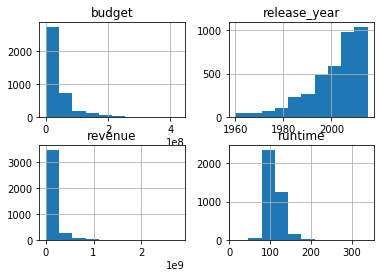

```python
TMDb_data.hist();
```

### 1. Which movie was most and least profitable?

Let's Insert column named 'profit_earned' which will be helpful in finding the max and min profit movie.

```python
#We will insert the function using following three parameters i.e index of the column in the dataset, name of the column, calculated value

TMDb_data.insert(2,'profit_earned',TMDb_data['revenue']-TMDb_data['budget'])

#verifying the changes in the dataset
TMDb_data.head(3)
```

|  | budget | revenue | profit_earned | original_title | cast | director | tagline | runtime | genres | release_date | release_year |
| --- | --- | --- | --- | --- | --- | --- | --- | --- | --- | --- | --- |
| 0 | 150000000 | 1513528810 | 1363528810 | Jurassic World | Chris Pratt\|Bryce Dallas Howard\|Irrfan Khan\|Vi... | Colin Trevorrow | The park is open. | 124 | Action\|Adventure\|Science Fiction\|Thriller | 2015-06-09 | 2015 |
| 1 | 150000000 | 378436354 | 228436354 | Mad Max: Fury Road | Tom Hardy\|Charlize Theron\|Hugh Keays-Byrne\|Nic... | George Miller | What a Lovely Day. | 120 | Action\|Adventure\|Science Fiction\|Thriller | 2015-05-13 | 2015 |
| 2 | 110000000 | 295238201 | 185238201 | Insurgent | Shailene Woodley\|Theo James\|Kate Winslet\|Ansel... | Robert Schwentke | One Choice Can Destroy You | 119 | Adventure\|Science Fiction\|Thriller | 2015-03-18 | 2015 |

As we see the column 'profit_earned' is inserted in the database

```python
import pprint
#defining the function
def calculate(column):
    #for highest earned profit
    high= TMDb_data[column].idxmax()
    high_details=pd.DataFrame(TMDb_data.loc[high])

    #for lowest earned profit
    low= TMDb_data[column].idxmin()
    low_details=pd.DataFrame(TMDb_data.loc[low])

    #To concatenate data in one place
    info=pd.concat([high_details, low_details], axis=1)

    return info

#calling the function
calculate('profit_earned')
```

|  | 1386 | 2244 |
| --- | --- | --- |
| budget | 237000000 | 425000000 |
| revenue | 2781505847 | 11087569 |
| profit_earned | 2544505847 | -413912431 |
| original_title | Avatar | The Warrior's Way |
| cast | Sam Worthington\|Zoe Saldana\|Sigourney Weaver\|S... | Kate Bosworth\|Jang Dong-gun\|Geoffrey Rush\|Dann... |
| director | James Cameron | Sngmoo Lee |
| tagline | Enter the World of Pandora. | Assassin. Hero. Legend. |
| runtime | 162 | 100 |
| genres | Action\|Adventure\|Fantasy\|Science Fiction | Adventure\|Fantasy\|Action\|Western\|Thriller |
| release_date | 2009-12-10 00:00:00 | 2010-12-02 00:00:00 |
| release_year | 2009 | 2010 |

Column with Id 1386 shows most profitable movie (Avatar) and the profit earned 2.5B USD. Column with Id 2244 shows least profitable movie (The Warrior's Way) with loss of 400M USD.

#### Let's create visual graphs to understand it better as whole picture covering all movies in dataset

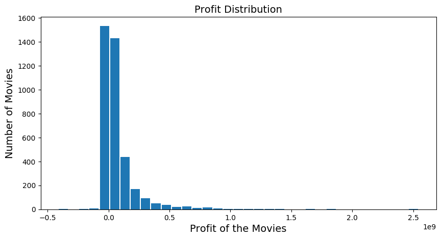

```python
#creating histogram of Profit
#giving the figure size(width, height)
plt.figure(figsize=(10,5), dpi = 100)

#On x-axis
plt.xlabel('Profit of the Movies', fontsize = 14)
#On y-axis
plt.ylabel('Number of Movies', fontsize=14)
#Name of the graph
plt.title('Profit Distribution', fontsize=14)

#giving a histogram plot
plt.hist(TMDb_data['profit_earned'], rwidth = 0.9, bins =35)
#displays the plot
plt.show()
```

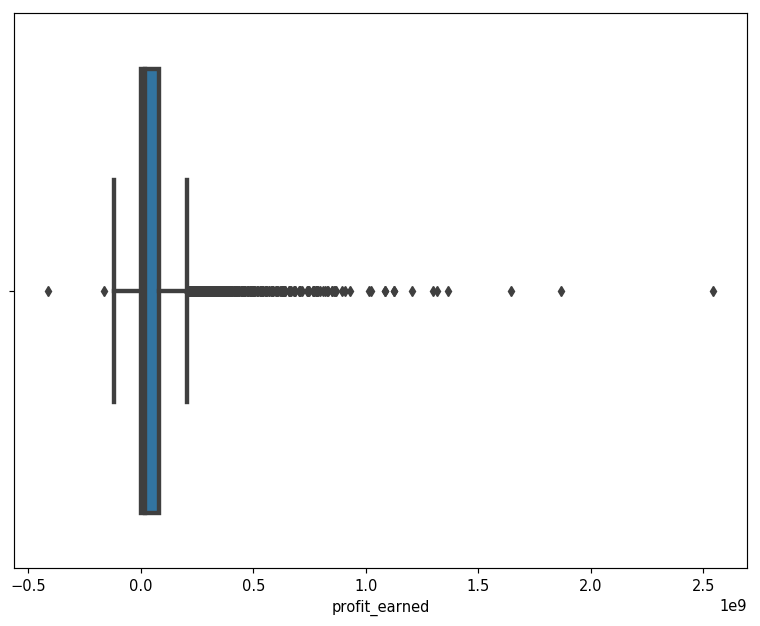

```python
import seaborn as sns
#The First plot is box plot of the runtime of the movies
plt.figure(figsize=(9,7), dpi = 105)

#using seaborn to generate the boxplot
sns.boxplot(TMDb_data['profit_earned'], linewidth = 3)
#diplaying the plot
plt.show()
```

### 2. Which movie had the greatest and least runtime?

```python
calculate('runtime')
```

|  | 2107 | 5162 |
| --- | --- | --- |
| budget | 18000000 | 10 |
| revenue | 871279 | 5 |
| profit_earned | -17128721 | -5 |
| original_title | Carlos | Kid's Story |
| cast | Edgar RamÃrez\|Alexander Scheer\|Fadi Abi Samra... | Clayton Watson\|Keanu Reeves\|Carrie-Anne Moss\|K... |
| director | Olivier Assayas | Shinichiro Watanabe |
| tagline | The man who hijacked the world | NaN |
| runtime | 338 | 15 |
| genres | Crime\|Drama\|Thriller\|History | Science Fiction\|Animation |
| release_date | 2010-05-19 00:00:00 | 2003-06-02 00:00:00 |
| release_year | 2010 | 2003 |

So we see that movie 'Carlos' has the greatest runtime 338 mins (around 5 and half hour) and movie 'Kid's Story' has the least runtime that is 15 mins. It will be interesting to see what was the average runtime of the movies. Let's see

```python
# defining function to find average of a column
def avg_col(column):
    return TMDb_data[column].mean()
```

```python
#calling function to show the mean
avg_col('runtime')
```

```
109.22029060716139
```

We see that the average runtime of movie is 109 mins. Let's try to convert it in visual form and have better understanding.

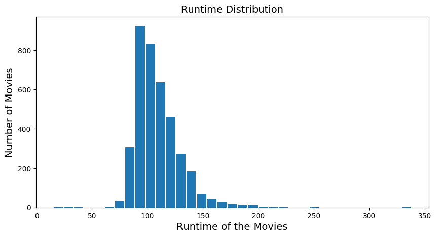

```python
#creating histogram of runtime of movies
#giving the figure size(width, height)
plt.figure(figsize=(10,5), dpi = 100)

#On x-axis
plt.xlabel('Runtime of the Movies', fontsize = 14)
#On y-axis
plt.ylabel('Number of Movies', fontsize=14)
#Name of the graph
plt.title('Runtime Distribution', fontsize=14)

#giving a histogram plot
plt.hist(TMDb_data['runtime'], rwidth = 0.9, bins =35)
#displays the plot
plt.show()
```

As we see the runtime distribution in the graph is positively skewed. Runtime for most of the movies is timed between 80 to 120 minutes approx. More than 1000 movies comes under this category.

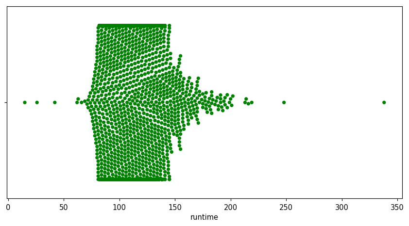

```python
plt.figure(figsize=(10,5), dpi = 105)
#using seaborn to generate the plot
sns.swarmplot(TMDb_data['runtime'], color = 'green')
#displaying the plot
plt.show()
```

### 3. Which movie had the Maximum and Minimum budget?

```python
calculate('budget')
```

|  | 2244 | 2618 |
| --- | --- | --- |
| budget | 425000000 | 1 |
| revenue | 11087569 | 100 |
| profit_earned | -413912431 | 99 |
| original_title | The Warrior's Way | Lost & Found |
| cast | Kate Bosworth\|Jang Dong-gun\|Geoffrey Rush\|Dann... | David Spade\|Sophie Marceau\|Ever Carradine\|Step... |
| director | Sngmoo Lee | Jeff Pollack |
| tagline | Assassin. Hero. Legend. | A comedy about a guy who would do anything to ... |
| runtime | 100 | 95 |
| genres | Adventure\|Fantasy\|Action\|Western\|Thriller | Comedy\|Romance |
| release_date | 2010-12-02 00:00:00 | 1999-04-23 00:00:00 |
| release_year | 2010 | 1999 |

This is interesting! We can see the high budget movie is 'The Warrior's Way' with total cost of 425M USD. On other side we see that lowest budget movie is with $1 budget. This is huge difference in budget of 2 movies. Let's create dot plot graph as visual presentation to have an overview on full budget statistics.

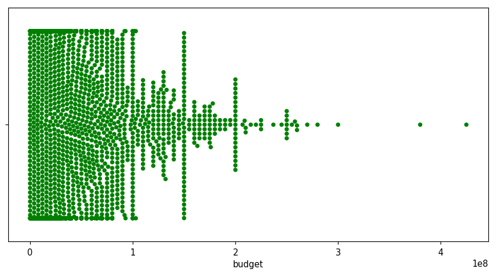

```python
plt.figure(figsize=(10,5), dpi = 105)
#using seaborn to generate the plot
sns.swarmplot(TMDb_data['budget'], color = 'green')
#displaying the plot
plt.show()
```

Above dot plot graph shows that most of the movies were having budget in the range of 0-50M. To extreme right there is one dot showing highest budget movie 'The Warrior's Way' for 425M USD.

```python
#Since we want to know the profits of movies for every year therefore we have to sum up all the movies of a particular year
per_year_profits = TMDb_data.groupby('release_year')['profit_earned'].sum()
#To find that which year made the highest profit?
per_year_profits.idxmax()
```

```
2015
```

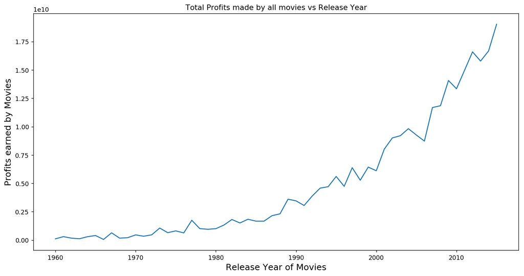

```python
#figure size(width, height)
plt.figure(figsize=(14,7), dpi = 130)

#on x-axis
plt.xlabel('Release Year of Movies', fontsize = 14)
#on y-axis
plt.ylabel('Profits earned by Movies', fontsize = 14)
#Line plot title
plt.title('Total Profits made by all movies vs Release Year')

#plotting the graph
plt.plot(per_year_profits)

#displaying the line plot
plt.show()
```

#### We will now find characteristics of profitable movies. Let's see what is the mean of all profit earned by movies in this dataset

```python
avg_col('profit_earned')
```

```
70482919.143227816
```

As we see the average profit is around 70 M which are including all mvoies. Let's consider movies which made significant amount of profits and clean dataset by removing movies which are in loss and movies which made profits only some dollars. Then we will then analyze similar characteristics of it. We will keep movies which made profit 50 M dollars or higher.

```python
#Selecting the movies having profit $50M or higher
profit_standard = TMDb_data[TMDb_data['profit_earned'] >= 50000000]

#reindexing new data
profit_standard.index = range(len(profit_standard))

#initiating dataframe from 1 instead of 0
profit_standard.index = profit_standard.index + 1

#printing the changed dataset
profit_standard.head(3)
```

|  | budget | revenue | profit_earned | original_title | cast | director | tagline | runtime | genres | release_date | release_year |
| --- | --- | --- | --- | --- | --- | --- | --- | --- | --- | --- | --- |
| 1 | 150000000 | 1513528810 | 1363528810 | Jurassic World | Chris Pratt\|Bryce Dallas Howard\|Irrfan Khan\|Vi... | Colin Trevorrow | The park is open. | 124 | Action\|Adventure\|Science Fiction\|Thriller | 2015-06-09 | 2015 |
| 2 | 150000000 | 378436354 | 228436354 | Mad Max: Fury Road | Tom Hardy\|Charlize Theron\|Hugh Keays-Byrne\|Nic... | George Miller | What a Lovely Day. | 120 | Action\|Adventure\|Science Fiction\|Thriller | 2015-05-13 | 2015 |
| 3 | 110000000 | 295238201 | 185238201 | Insurgent | Shailene Woodley\|Theo James\|Kate Winslet\|Ansel... | Robert Schwentke | One Choice Can Destroy You | 119 | Adventure\|Science Fiction\|Thriller | 2015-03-18 | 2015 |

```python
#Checking how many rows showing profit 50M or above
len(profit_standard)
```

```
1338
```

So now we have dataset including 1338 rows which earlier were 3853. So one more conclusion that 2515 movies are such which made profit less than 50M.

### 5. Which genres were more successful?

```python
#Defining function which will take any column as argument
def data_func(column):
    #Will take a column, and separate the string by '|'
    data = profit_standard[column].str.cat(sep = '|')

    #Assigning pandas series and storing the values separately
    data = pd.Series(data.split('|'))

    #Arranging in descending order
    count_genre = data.value_counts(ascending = False)

    return count
```

```python
#variable to store the retured value
count_genre = data('genres')
#printing top 5 values
count_genre.head()
```

[output not shown]

Let's create visual representation :

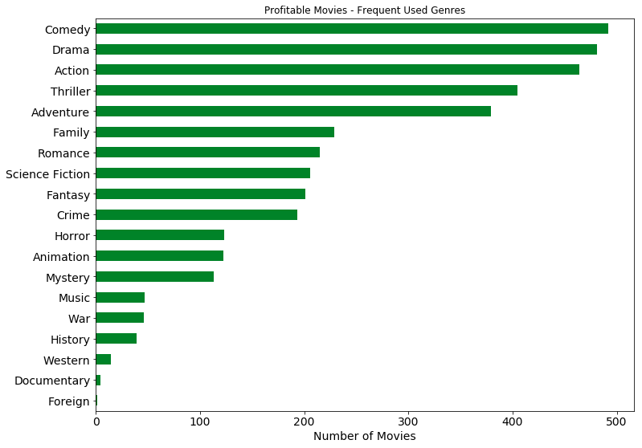

```python
#lets plot the points in descending order top to bottom as we have data in same format.
count_genre.sort_values(ascending = True, inplace = True)

#ploting
lt = count_genre.plot.barh(color = '#008328', fontsize = 14)

#title
lt.set(title = 'Profitable Movies - Frequent Used Genres')

# on x axis
lt.set_xlabel('Number of Movies', color = 'black', fontsize = '14')

#figure size(width, height)
lt.figure.set_size_inches(12, 9)

#ploting the graph
plt.show()
```

We can conclude Comedy movies are most popular genre for this dataset.

### 6. Which cast has appeared the most?

```python
#this will variable will store the return value from a function
cast_count = data('cast')
#shwoing top 5 values
cast_count.head()
```

[output not shown]

Woah! Tom Cruise was popular in this time followed by Brad Pitt

### 7. Directors with maximum releases over the years?

```python
#this will variable will store the return value from a function
director_count = data('director')
#shwoing top 5 values
director_count.head()
```

[output not shown]

### 8. Which month made the most profit?

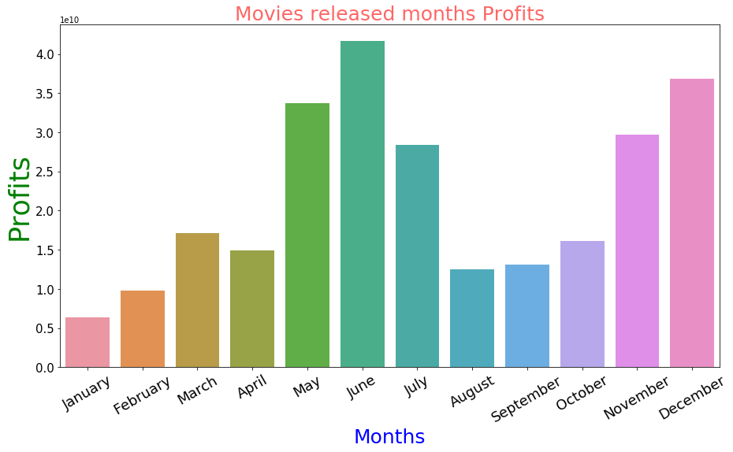

```python
#To answer this question grouping all of the months of years and then calculating the profits of those months
#Assinging new dataframe which gives 'release-date' as index
release_date_index = profit_standard.set_index('release_date')

#now we need to group all the data by month, since release date is in form of index, we extract month from it
groupby_index = release_date_index.groupby([(release_date_index.index.month)])

monthly_profit = groupby_index['profit_earned'].sum()

#converting table to a dataframe
monthly_profit = pd.DataFrame(monthly_profit)

#plotting seaborn bar plot to visualize the data
#assigning values to our graph
monthly_profit_bar = sns.barplot(x = monthly_profit.index, y = monthly_profit['profit_earned'], data = monthly_profit)

#setting size of the graph
monthly_profit_bar.figure.set_size_inches(15,8)

#setting the title and customizing
monthly_profit_bar.axes.set_title('Movies released months Profits', color="r", fontsize = 25, alpha = 0.6)

#setting x-label
monthly_profit_bar.set_xlabel("Months", color="b", fontsize = 25)
#setting y-label
monthly_profit_bar.set_ylabel("Profits", color="g", fontsize = 35)

#customizing axes values
monthly_profit_bar.tick_params(labelsize = 15, labelcolor="black")

#rotating the x-axis values to make it readable
monthly_profit_bar.set_xticklabels(month_list, rotation = 30, size = 18)

#shows the plot
plt.show()
```

This is Interesting! We can see that Movies made most profits in month of June followed by December. It could be also due to Summer holidays and Christmas holidays that viewrship increases when people have more free time. Also we see that movie **Avatar** was released in Decemeber(2009-12-10) as well but also least profit movie **The Warrior's Way** was also released in December (2010-12-02). This representation shows that chances are higher for profits if released in above high profit months, but also it depends on other factors such as story,cast,directors etc.

### 9. What is average budget for profitable movie ?

```python
#New function to find average
def average_profit(column):
    return profit_standard[column].mean()
```

```python
# calling the above function for budget
average_profit('budget')
```

```
60444957.760837071
```

The result shows that the average budget is 60 million dollar for movies having profit 50M and higher

### 10. What is the average runtime for profitable movies ?

```python
#calling the above function for average runtime
average_profit('runtime')
```

```
113.66741405082212
```

As seen above the movies with profit 50M or higher has average duration/runtime of 113 mins.

## Conclusions

From all the results found above conclusion for profitable movies can be made that :

- Genre of movie should be Comedy (1st), Drama (2nd) or Action (3rd)
- Cast can be chosen from Tom Cruise, Brad Pitt, Tom Hanks, Sylvester Stallone, Cameron Diaz
- Preferable Month for Movie release date are June, December, May, November, July
- The average budget for profitable movie around 60 million dollar.
- The average runtime for profitable movie around 113 mins.
- Directors can be chosen from Steven Spielberg, Robert Zemeckis, Clint Eastwood as most experienced ones.

## Limitations

We should keep in mind that above analysis is only pointing towards the characteristics for higher chances of profitabilty. The dataset provided to analyze is time-bound and trendz do change over period of time. Also, in dataset currency is not defined so we are assuming the profits are in USD but may be it also includes profits from other countries and currencies as well. Therefore, above characteristics are helpful to generate people's attraction to movie and therefore results in high profitabilty. Other than this, there are also other important influential factors like story,movie marketing etc on which profitability depends.

```python
from subprocess import call
call(['python', '-m', 'nbconvert', 'Investigate_a_Dataset.ipynb'])
```